# Preprocessing/Cleaning

## Analysis of missing mechanism

- **MCAR (Missing Completely at Random)**: the probability of missingness is unrelated to both observed and unobserved data. In this case, missing values occur purely by chance, dropping incomplete cases does not introduce bias.
- **MAR (Missing at Random)**: the probability of missingness may depend on observed variables, but conditional on those observed variables, it does not depend on the missing value itself.
- **MNAR (Missing Not at Random)**: the probability of missingness still depends on the unobserved value itself, even after conditioning on observed data. This cannot be verified directly from the observed data alone, because the mechanism depends on values that are not observed.

In practice, these mechanisms cannot usually be distinguished with certainty from the observed data alone, especially in distinguishing MAR and MNAR. Therefore, rather than attempting to verify MAR directly, we assess its plausibility indirectly using the following diagnostic strategies:

- **Assess whether missingness is explainable by observed data**: model the missingness indicator using baseline covariates, lagged outcomes, and other observed variables. If missingness can be substantially explained by observed information, the MAR assumption becomes more plausible.
- **Include strong auxiliary variables**: add variables that are highly predictive of the missing outcome or of the missingness process into the imputation or likelihood-based model. This can reduce bias and strengthen the plausibility of MAR.
- **Check robustness under MAR-based methods**: compare results across approaches such as complete-case analysis, IPW, FIML, and MI under the same observed-data structure. Similar conclusions make MAR-based inference more credible.
- **Conduct MNAR sensitivity analysis**: evaluate how conclusions change under plausible departures from MAR using methods such as pattern-mixture models, selection models, or delta-adjusted imputation. Stable results suggest that the main findings are not overly sensitive to violations of MAR.

### Proving data is not MCAR

Each student’s outcome record is summarized by a four-digit indicator over grades K, 1, 2, 3, where 1 denotes an observed math score and 0 denotes a missing math score. For example, 1111 indicates complete observation across all four grades and 1001 indicates a non-monotone pattern with observation in K and Grade 3 but missingness in between.

We classified the K–3 observation patterns into five descriptive groups:

- Pattern 1111 was defined as **complete cases**.
- Patterns 1110, 1100, 1000, 0100, and 0110 were grouped as **monotone attrition**, since once students entered a missing state, they did not subsequently return to full follow-up.
- Patterns 0011 and 0001 were classified as **late entry**, as observations only began in later grades.
- Patterns 1010, 1001, 0101, 0010, and 1011 were classified as **intermittent**, reflecting non-monotone missingness with reappearance after one or more missing waves, this is the most possible group whose missing at random.
- Pattern 0111 was separated as **no records in K**, because it there are a specific group of students who hasn’t got kindergarten but observed continuously from Grade 1 onward.

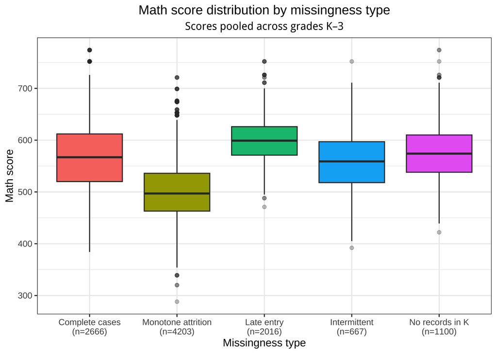

```r
wide <- stars1 %>% mutate(obs = !is.na(math_score)) %>%
  select(student_id, grade, obs) %>%
  pivot_wider(names_from = grade, values_from = obs)

wide <- wide %>% mutate(K = ifelse(is.na(K), FALSE, K),
    `1` = ifelse(is.na(`1`), FALSE, `1`),
    `2` = ifelse(is.na(`2`), FALSE, `2`),
    `3` = ifelse(is.na(`3`), FALSE, `3`))

wide <- wide %>% mutate(pattern = paste0(K*1, `1`*1, `2`*1, `3`*1))

wide <- wide %>% filter(pattern != "0000") %>%
  mutate(complete = ifelse(pattern == "1111", "Complete", "Incomplete"))

stars_plot <- stars1 %>% left_join(wide %>% select(student_id, pattern), by = "student_id") %>%
  filter(!is.na(pattern), pattern != "0000", !is.na(math_score))

pattern_order <- stars_plot %>% distinct(student_id, pattern) %>% count(pattern, sort = TRUE) %>% pull(pattern)
pattern_order <- c("1111", setdiff(pattern_order, "1111"))

stars_plot2 <- stars1 %>%
  left_join(wide %>% select(student_id, pattern), by = "student_id") %>%
  filter(!is.na(pattern), pattern != "0000", !is.na(math_score)) %>%
  mutate(pattern_class = case_when(pattern == "1111" ~ "Complete cases",
      pattern %in% c("1110", "1100", "1000", "0100", "0110") ~ "Monotone attrition",
      pattern %in% c("0011", "0001") ~ "Late entry",
      pattern %in% c("1010", "1001", "0101", "0010", "1011") ~ "Intermittent",
      pattern %in% "0111" ~ "No records in K",
      TRUE ~ NA_character_)) %>%
  filter(!is.na(pattern_class))

class_count <- stars_plot2 %>% distinct(student_id, pattern_class) %>% count(pattern_class)

class_labels <- class_count %>% mutate(label = paste0(pattern_class, "\n(n=", n, ")")) %>%
  {setNames(.$label, .$pattern_class)}

stars_plot2 <- stars_plot2 %>%
  mutate(pattern_class = factor(pattern_class,
                                levels = c("Complete cases","Monotone attrition",
                                           "Late entry", "Intermittent", "No records in K")))

p3 <- ggplot(stars_plot2, aes(x = pattern_class, y = math_score, fill = pattern_class)) +
  geom_boxplot(outlier.alpha = 0.3) +
  scale_x_discrete(labels = class_labels) +
  labs(title = "Math score distribution by missingness type",
    subtitle = "Scores pooled across grades K–3",
    x = "Missingness type",
    y = "Math score") +
  theme_bw() +
  theme(plot.title = element_text(hjust = 0.5),
    plot.subtitle = element_text(hjust = 0.5),
    legend.position = "none")
p3
```

The boxplot shows clear differences in pooled math-score distributions across missingness types from kindergarten to Grade 3. The pooled math-score distributions suggest that complete cases, intermittent cases, have broadly similar achievement levels. However, the monotone attrition group has lower math score while the late-entry group shows the significantly higher math score among all categories. The pattern suggests that missingness type is related to student performance, which is inconsistent with a purely MCAR mechanism. Thus, missingness type itself is informative and should be analyzed specifically.

## Examine whether missingness can be explained by observed variables

```r
baseline_vars <- c("math_score", "free_lunch", "student_race",
  "student_gender", "class_type", "area_type","class_size")

stu_base <- stars1 %>% arrange(student_id, grade) %>%
  group_by(student_id) %>% slice(1) %>%
  ungroup() %>%
  select(student_id, all_of(baseline_vars)) %>%
  left_join(wide %>% select(student_id, complete), by = "student_id")

tab <- CreateTableOne(vars = baseline_vars, strata = "complete",
  data = stu_base, test = TRUE)
tab_mat <- print(tab, smd = TRUE, quote = FALSE, noSpaces = TRUE, printToggle = FALSE)
tab_df  <- as.data.frame(tab_mat)
tab_df$Variable <- c("n", "Math score, mean (SD)", "Free lunch: Non-free lunch, n (%)",
  "Student race: Non-Black, n (%)", "Student gender: Female, n (%)",
  "Class type: Small class, n (%)",  "Area type, n (%)", "  Inner City", "  Rural",
  "  Suburban", "  Urban", "Class size, mean (SD)")
tab_df <- tab_df[, !names(tab_df) %in% "test"]
tab_df <- tab_df[, c("Variable", setdiff(names(tab_df), "Variable"))]
rownames(tab_df) <- NULL
knitr::kable(tab_df, caption = "Baseline characteristics by completeness status")
```

Baseline characteristics by completeness status

| Variable | Complete | Incomplete | p | SMD |
| --- | --- | --- | --- | --- |
| n | 2666 | 8104 |  |  |
| Math score, mean (SD) | 498.85 (44.58) | 474.17 (47.31) | <0.001 | 0.537 |
| Free lunch: Non-free lunch, n (%) | 1682 (63.2) | 1491 (43.1) | <0.001 | 0.412 |
| Student race: Non-Black, n (%) | 2009 (75.4) | 4813 (59.6) | <0.001 | 0.341 |
| Student gender: Female, n (%) | 1367 (51.3) | 3714 (45.8) | <0.001 | 0.109 |
| Class type: Small class, n (%) | 831 (31.2) | 1020 (29.3) | 0.122 | 0.041 |
| Area type, n (%) |  |  | <0.001 | 0.429 |
| Inner City | 402 (15.1) | 973 (28.0) |  |  |
| Rural | 1544 (57.9) | 1323 (38.0) |  |  |
| Suburban | 515 (19.3) | 840 (24.1) |  |  |
| Urban | 205 (7.7) | 344 (9.9) |  |  |
| Class size, mean (SD) | 19.97 (3.88) | 20.58 (4.02) | <0.001 | 0.154 |

### Include strong auxiliary variables

```r
stars1 <- stars1 %>%
  arrange(student_id, grade) %>%
  group_by(student_id) %>%
  mutate(math_lag1 = lag(math_score, 1),
    math_lag2 = lag(math_score, 2),
    math_lag3 = lag(math_score, 3)) %>% ungroup()
cont_vars <- c("treads", "tlists", "wordsk", "motivr", "readbs", "mathbs", "math_lag1", "math_lag2", "math_lag3")

cor_df <- map_dfr(cont_vars, function(v) {
  tmp <- stars1 %>% select(math_score, all_of(v)) %>%
    filter(!is.na(math_score), !is.na(.data[[v]]))

  tibble(variable = v, n = nrow(tmp),
    correlation = cor(tmp$math_score, tmp[[v]], use = "complete.obs", method = "pearson"))
}) %>% arrange(desc(abs(correlation)))

cor_df
```

```
## # A tibble: 9 × 3
##   variable      n correlation
##   <chr>     <int>       <dbl>
## 1 treads    24179       0.876
## 2 wordsk    23883       0.854
## 3 tlists    24398       0.838
## 4 math_lag1 13504       0.807
## 5 mathbs    18295       0.756
## 6 math_lag2  7236       0.654
## 7 readbs    18227       0.599
## 8 motivr    21785       0.526
## 9 math_lag3  2887       0.478
```

We examined the auxiliary variables including reading score (treads), word skills (wordsk), listening score (tlists), and lagged math scores. They have shown strong correlations with math achievement, which is informative for predicting missing math outcomes and can be included in the imputation model to reduce bias. This could be considered a case of satisfying the MAR assumption.